# Introduction à l’économie écologique

UC6 - Economie Ecologique

Simon Jean

simon.jean@agroparistech.fr

AgroParisTech - CIRED - PSAE

# Présentation du cours

## Programme détaillé

### 18 mars

- **08h30-12h30 :** Introduction à l’économie écologique : histoire du champ et perspectives épistémologiques
- **13h30-17h :** Analyse métabolique des sociétés
  - Cours magistral
  - Workshop analyse de données MFA via l’API d’Eurostat
- **17h-18h30 :** Travail en groupes

### 19 mars

- **08h30-12h30 :** Vers une macroéconomie écologique
  - Cours magistral
  - Exercices de modélisation: de `World 3` à `Low Grow`
- **13h30-16h :** Conservation de la biodiversité
  - Cours magistral et lectures critiques
- **16h00-18h30 :** Travail en groupes

### 21 mars

- **08h30-12h30 :** Penser les transitions institutionnelles à différentes échelles
  - Mise en situation: gestion d’une nappe phréatique commune
  - Cours magistral
- **13h30-14h30 :** Perspectives contemporaines et conclusion générale
- **14h30-18h30 :** Évaluation

## Ressources

De façon générale, je vous conseille de feuilleter :

- *L’économie écologique*, d’Ali Douai et Gaël Plumecocq, La découverte
- *An Introduction to Ecological Economics*, de Robert Costanza, John Cumbeland, Herman Daly etc
- *Handbook of Ecological Economics*, Joan Martinez Allier et Roldan Muradian

Il y aura des articles suggérés pour chaque séance, à lire en avance ou pour approfondir les sujets traités

Je me suis inspiré des travaux de beaucoup de collègues, que je remercie:

- [Quentin Couix, MC à l’UPEC](https://scholar.google.com/citations?user=1U-2fJMAAAAJ&hl=en)
- [Luc Elie, chercheur au CIRED](https://scholar.google.fr/citations?user=FqctPIMAAAAJ&hl=fr)
- [Charles Claron, doctorant au CIRED](https://www.researchgate.net/profile/Charles-Claron-2)
- [Harold Levrel, professeur au MNHN](https://www.researchgate.net/profile/Harold-Levrel)

## Modalités d’évaluation

Evaluation sous la forme d’un débat durant la dernière séance, basée sur :

- L’oral : en fonction de la qualité du débat, des arguments etc
  - Structuration par groupes de 5
  - Deux POUR/deux CONTRE
  - Un.e. *chair person*, dont le rôle sera :
    - D’introduire les éléments factuels du débat
    - Poser les termes du débat : questions, sous questions etc
    - Organiser le vote
    - Animer le débat : distribution du temps de parole, interventions si informations fausses, recadrage etc
  - Pensez à bien décortiquer le sujet, bien essayer d’en traiter les différentes dimensions : efficacité, quels changement institutionnels sont nécessaires etc
- Un rendu écrit avec les recherches préliminaires et un argumentaire critique sur le sujet choisi de 2-3 pages, comprenant:
  - Une introduction théorique et historique: dans quel contexte se pose la question?
  - Un argumentaire structuré, mobilisant apports théoriques et empiriques, sous la forme d’un plan détaillé
  - Une conclusion définitive quant à votre argument
  - Une bilbliographie détaillée aux standards académiques

Avant et après le débat, il y aura un vote, pour voir si les avis ont changé.

- Chaque débat durera environ 35 minutes:
  - 4 minutes d’introduction par la chair person
  - 28 minutes alternance d’intervention entre les deux équipes (maximum 14 minutes par équipe)
  - 3 minutes d’ajustement par le.a chair et vote final
- Voici la liste des sujets proposés :
  - Pour ou contre les OGM?
  - Faut il créer une Organisation Mondiale pour l’Environnement?
  - L’économie circulaire est-elle une alternative viable?
  - Faut il taxer la consommation de viande?
  - Le Green New Deal est il une perspective suffisante?
  - Pour ou contre la décroissance?
  - Pour ou contre la compensation écologique?
  - Faut il donner des droits aux rivières?
- Je vous partagerai des ressources si vous le souhaitez
- Durant les heures de travail en groupe :
  - Formez des groupes
  - Décortiquez le sujet: définissez tous les termes, et posez vous les questions autour des termes : verbes, modalités, concepts
  - Cherchez l’histoire des concepts employés
  - Utilisez des techniques de recherche modernes :
    - Google Scholar
    - Research Rabbit ou Connected Papers
  - Cherchez dans des journaux scientifiques établis : journaux du portfolio Nature ou Science
  - Cherchez dans les rapports des puissances publiques nationales (Cour des Comptes, Assemblée Nationale…), universitaires (INRAE…) et étrangères
  - Vous pouvez me demander de l’aide

# Plan de la séance

1. Introduction
2. Overview historique des courants de pensée
3. Points clés de l’économie écologique
4. L’économie écologique aujourd’hui: différents courants de pensée

# Introduction

## Contexte

- Au début des années 1970, la question environnementale prend de l’ampleur
  - Par les dégradations observées
  - La prise de conscience publique
  - Et intellectuelle : de nombreux penseur.e.s parlent de notre lien à la nature
- L’économie mainstream semble incapable de penser la finitude des ressources et les questions qu’elle pose
- Une nouvelle branche transdisciplinaire émerge à la croisée des chemins entre sciences naturelles et économie pour y réfléchir

## (Première) définition

C’est un champ de recherche

- interdisciplinaire
  - Qui travaille à l’intersection des disciplines : écologie (scientifique, industrielle, énergétique etc) et économie
- et transdisciplinaire
  - Qui dépasse les liens académiques et vise à oeuvrer sur la société
- qui étudie l’interdépendance et la coévolution
- des écosystèmes et économies humaines
- dans l’espace et le temps
- afin de garantir la soutenabilité des sociétés humaines

# Une brève histoire de la pensée en économie écologique

## Approches biophysiques et allocative

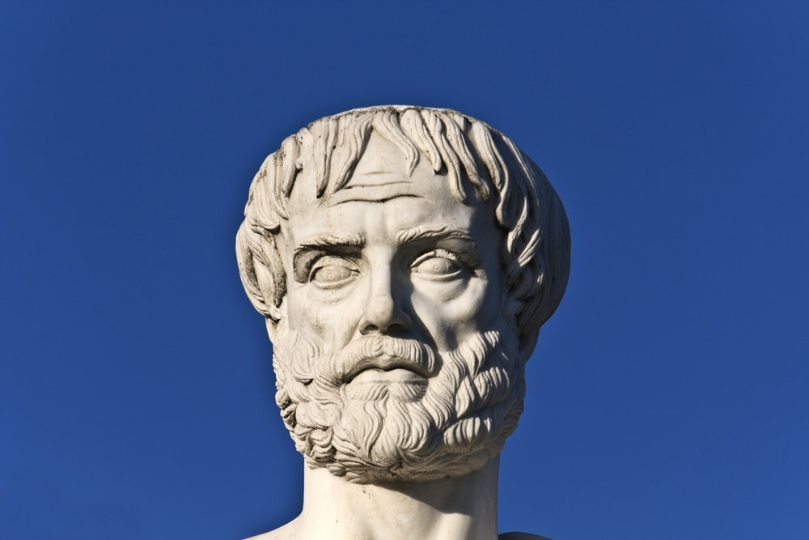

Principes de pensée suivant la :

- chrématistique : l’art de l’acquisition des richesses
- l’oikonomia: bien administrer les ressources d’un foyer (oikos, “maison”) en vue du bien-vivre

Que l’on retrouve dans l’histoire de la pensée économique :

- Tradition biophysique : Une vision matérialiste des processus économiques comme des flux et des stocks d’énergie et de matière, soumis aux lois de l’entropie et aux sources de subsistance.
- Tradition allocative : étudie une relation de cause à effet avec les prix du marché, envisagée en termes de défaillances de marché, d’allocation efficace et d’un concept de l’utilité marginale orienté par la demande, sans lien avec le monde physique

## A. Précurseurs : ressources naturelles et contraintes sur la croissance économique

- La terre est à la source de la valeur dans les théories économiques du XVIIIe siècle, qu’elle soit d’*usage ou d’échange*
- Le secteur agricole, prédominant à l’époque, est au coeur des préoccupations : les disettes peuvent encore arriver
- Le rapport à la nature de l’économie se fait sous l’angle de la terre, ancrant une tradition biophysique

Dans quelle mesure la terre, ses produits et leur répartition peut être un frein ou moteur à la croissance?

### Les physiocrates et François Quesnay (1694-1774)

Ecole de pensée juridique, politique et économique, France, milieu du XVIIIe siècle

- Etymologie : “gouvernement par la nature” : théorie de la richesse et de sa distribution à destination du roi
  - Une livre de grains plantés en donne 5, créant un produit net une fois la survie des agriculteurs actée
  - Toute la richesse vient de la terre *ergo* la seule classe productive est celle des agriculteurs
  - C’est ce produit net qui guide la richesse
- Les autres activtés, industrielles ou artisanales, transforment mais ne créent pas de valeur en soi, ils sont “improductifs”, ou “stériles”
- Au milieu, les propriétaires (clergé, noblesse), perçoivent le produit net de l’agriculture
- Conception synthétisée par le Tableau Economique de Quesnay (1758), chef de file des physiocrates et médecin
  - Issu de nombreux flux, en analogie avec la circulation du sang dans le corps humain
  - Peu clair, il illustre néanmoins la circulation des flux dans l’économie basés sur la matière
  - Il inspirera toutes les entreprises de comptabilité économiques basées sur la matière, comme Leontieff

[figure not shown]

### Adam Smith (1723-1790) et la croissance

*Essai sur la Nature et les Causes de la Richesse des Nations*, 1776

- L’industrialisation est non pas stérile, comme chez Quesnay, mais à la source de l’augmentation de la productivité, donc du développement économique
- La terre peut être mieux cultivée, si l’on y apporte du capital : la productivité augmente
- On peut produire autant avec moins de monde, ce qui accroît la puissance de l’industrie
  - Ou produire plus
- Cela permet de dégager un développement économique et absorber une croissance de la population dans de bonnes conditions

[figure not shown]

### Robert Malthus (1766-1834) et la croissance démographique

*Essai sur le principe de population*, 1798

[figure not shown]

- L’augmentation de la population s’accompagne d’une grande pauvreté :
  - L’exode rural des activités productives (l’industrie et activités artisanales) rend la prise en charge des nécessiteux dans les milieux ruraux plus difficile, accentuant l’exode rural
  - L’oeuvre de Malthus doit se comprendre dans le cadre des *“poor laws”*, qui selon lui permettent une croissance démographique insoutenable
- En utilisant les données d’Amérique du Nord, il argue d’une croissance géométrique de la population
- Du fait des rendements décroissants et de la fixité de l’offre de terre agricole, la production agricole ne pourrait croître que de façon arithmétique
  - Il convient de la possibilité d’ouvrir de nouveaux territoires, mais à long terme
  - La loi des rendements décroissants n’est pas encore etayée empiriquement
- Il y aura donc des contrôles de la population par pénurie alimentaire
  - Ce serait bien d’éviter cet ajustement brutal
  - Méthodes “positives” (guerre, famine et peste) ou “préventives” (contraception, avortement, retenue morale)
  - L’amélioration de la médecine et des conditions sanitaires aggravent le problème
  - Aider les pauvres est improductif est même nocif, offrant une justification pour les conservateurs, pour ne rien faire.
- A posteriori, d’importants gains de productivité ont été réalisés en Grande Bretagne, et une transition démographique
- La question de la limitation des ressources et les conclusions dressées par Malthus
  - Donnent lieu au Malthusianisme, pronant le contrôle démographique actif, et négativement connoté
  - Utilisée parfois pour dénigrer les travaux mettant en exergue les limites

### David Ricardo (1772-1823) : ressources, rareté, croissance

*Principes d’économie politique et de l’impôt* (1817)

- Les embargos sur les ports anglais pendant les guerres napoléoniennes
  - Causent une mise en culture des terres moins fertiles (aux coûts les plus haut)
  - Accentuent la hausse des prix des céréales pour le public, et les rentes des puissants
  - Mennent à un retard économique, car les coûts de l’industrie étaient liés aux coût du blé (salaires), nécessaire à la force de travail
- Les bourgeois veulent et obtiennent en 1815, les *Corn Laws* limitaient l’importation des céréales en dessous d’un prix plancher.
- Ricardo s’y oppose :
- Les terres agricoles sont inégalement fertiles, ou ont des coûts de production hétérogènes
- Du fait de la croissance de la population, des terres de moins en moins fertiles sont cultivées.
- Les dernières à être cultivées sont les terres marginales, dont les produits ne couvrent que la main d’oeuvre et le capital investi.
  - Si le produit du blé était inférieur aux coûts, on ne cultiverait pas, s’il était au dessus, on cultiverait d’autres terres encore moins fertiles
- Deux conclusions émergent:
  - A la limite, un état stationnaire risque d’émerger où les terres limitent non plus seulement la population mais l’expansion économique
  - Il faut permettre l’importation du blé pour éviter que le capital afflue vers des terres pas très productives, laissons cela aux autres

### Jeremy Bentham : l’essor de la communauté morale (1748-1832)

[figure not shown]

- Il développe le paradigme utilitariste:
  - Doctrine philosophique et mode de raisonnement
  - Le but est d’atteindre le maximum des plaisirs et le minimum des peines du plus grand nombre, dans le temps également
- Dans l’utilitarisme, le vivant au sens large a une grande place :
  - Ils sont inclus dans la communauté morale via une approche antispéciste
  - La question n’est pas peuvent ils raisonner, mais peuvent ils souffrir?

### John Stuart Mill (1806-1873)

*Principes d’économie politique*, 1848

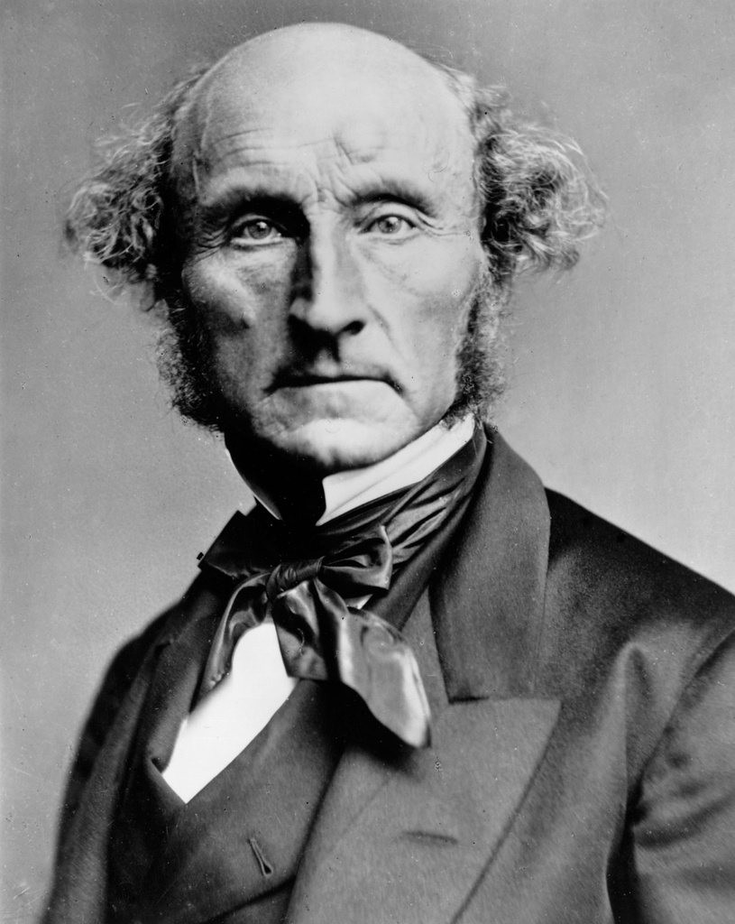

- Dans la nature, la croissance n’est pas un processus infini
- C’est pareil en économie, elle doit aboutir à un équilibre durable
- Dans son analyse, cette croissance n’est pas souhaitable:
  - Un monde surpeuplé et surexploité n’est pas enviable
  - Il espère que l’humanité se régulera
  - L’état stationnaire comme état désiré, librement choisi, avant qu’il soit imposé par la nature
- Passé un certain moment, l’accroissement des richesses ne répond plus aux problèmes les plus importants de la société
  - Le vrai problème, dans les pays riches, c’est la répartition

## B. Le tournant du XIXe siècle

### Les révolutions en sciences naturelles : la thermodynamique, Sadi Carnot (1796-1832)

La thermodynamique: “physique de la chaleur”, bases des moteurs etc, notamment grâce au physicien Sadi Carnot

- 1ere loi, la conservation de l’énergie : pour toute quantité d’énergie transformée, la quantité demeure constante
- 2e loi : toutes les énergies ne se transforment pas de la même manière
  - Par exemple, l’énergie thermique se change mal en énergie mécanique
  - Il en résulte que irréversiblement, la qualité de l’énergie disponible décroît
  - Beaucoup de phénomènes physiques sont donc irréversibles

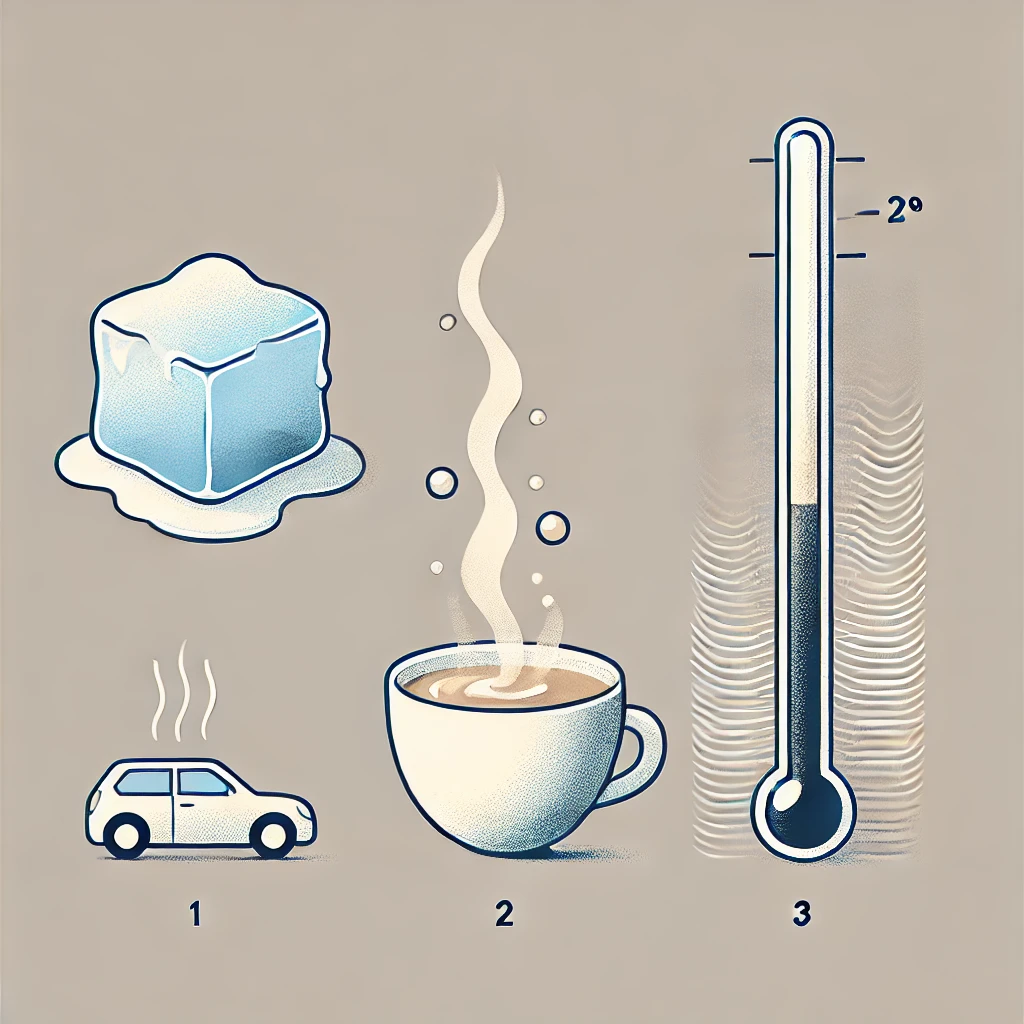

### Les révolutions en sciences naturelles : l’évolution, Charles Darwin, 1809-1892

Darwin, *L’Origine des espèces (1859)*, explique

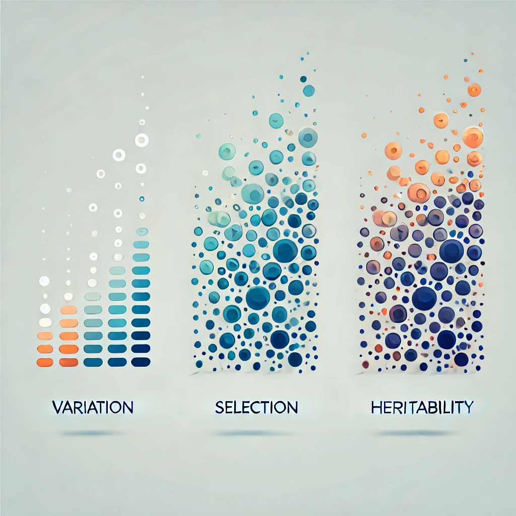

- Les organismes évoluent par sélection naturelle:
  - Seuls les traits favorables à la survie et à la reproduction se perpétuent
  - L’économie comme un système dynamique dans lequel les innovations, les institutions et les pratiques économiques subissent elles aussi des processus de « sélection » (économique, technologique, sociale).
  - L’économie est ainsi perçue comme un ensemble d’agents et de structures qui s’adaptent aux contraintes – notamment celles imposées par l’environnement – et aux ressources limitées.

### Les révolutions en sciences naturelles : l’écologie systématique, Haeckel, 1834-1919

- Pose le terme d’écologie: perspective holistique, qui considère les êtres vivants comme parties intégrantes d’un réseau complexe
- Idée que la nature fonctionnait comme un tout unifié, où chaque élément—qu’il soit vivant ou non—interagit avec les autres.
- Interactions réciproquesentre les espèces et leur environnement :
  - Haeckel a anticipé les principes de co-évolution et d’interdépendance
  - que l’on retrouve dans l’économie écologique contemporaine.

[figure not shown]

### William Stanly Jevons (1835-1882) et le problème du charbon, un marginaliste biophysique

[figure not shown]

- Avec l’essor industriel, le charbon devient une question :
  - Principale source d’énergie dans les pays qui s’industrialisent, remplaçant le bois dont les usages étaient rivaux et mettait en danger les forêts
  - Les ressources deviennent disponibles en quantité finie
  - Entre le XVI et le XIX siècle : la consommation de charbon par habitant a augmenté d’un multiple d’environ 45 au cours de ces trois siècles
- S’intéresse à tout autour du charbon : évolution des prix, coûts d’extraction, réserves etc
- C’est la principale source de compétitivité anglaise selon lui
  - Cela permet une chaine d’innovations: sans charbon pas cher, les premières machines à vapeur, inefficaces, n’auraient pas été utilisées et raffinées
- La rareté relative du charbon est à la source de sa croissance :
  - Si le prix augmente, on freine la croissance
  - Si les autres pays découvrent de meilleurs gisements, on perd l’avantage comparatif
- La rareté absolue joue aussi :
  - Le charbon remplace la terre chez Ricardo, sauf que la quantité de charbon va décroitre : on risque non un état stationnaire, mais un état de régression
  - Il pourrait y avoir une amélioration technique, mais suivie d’un effet rebond (qu’il est le premier à suggérer)
- Un des fondateurs de la révolution marginaliste, mais assez proche des classiques sur la question du charbon

### Podolinsky (1850-1891) et l’énergétisme social

[figure not shown]

- Médecin, économiste et militant ukrainien, redécouvert dans les années 1980
- *Le Socialisme et l’Unité des Forces de la Physique*, 1880 porte sur l’importance de l’énergie pour l’économie
  - Une harmonisation de lathéorie économique marxiste et des sciences naturelles
  - Etudie la capacité du travail humain à accumuler, dans ses produits une plus grande quantité d’énergie que celle qui a du être dépensée pour la production de la force des travailleurs
  - Description de la répartition générale de l’énergie sous forme utile à l’homme etde la capacité de travail humain à augmenterl’accumulation de l’énergie solaire sur terre
- Enonce lesprincipes de la thermodynamique:
  - Les plantes ont la capacité de transformer l’énergie solaiere
  - Les animaux en transforment une partie en travail mécanique et dissipe en énergie thermique le reste
  - Il faut gérer les cycles, notamment bien gérer l’agriculture
- Podolinsky étudie la capacité du travail humain appliqué à l’agriculture à accroître la quantité d’énergie solaire accumulée sur Terree par les plantes
  - s’appuie sur des statistiques agricoles françaises pour différentes culture
  - Il évalue la quantité d’énergie accumulée annuellement par hectare pour chacune de ces cultures, estime le gain dû au travail animal et humain,
  - pour finir par évaluer lenombre de calories supplémentaires accumulées grâce à une calorie de travail.
- Il aboutit à une estimation selon laquelle le travail humain et animal permet une accumulation de calories supplémentaires égale à 40 fois l’énergie dépensée pour une prairie artificielle, et 20 fois pour du blé
- Fonde une approche qualifiée d’“énergétisme social”, tenante d’une vision essentiellement biophysique des rapports entre économie et environnement

### Transition marginaliste et l’économie des ressources

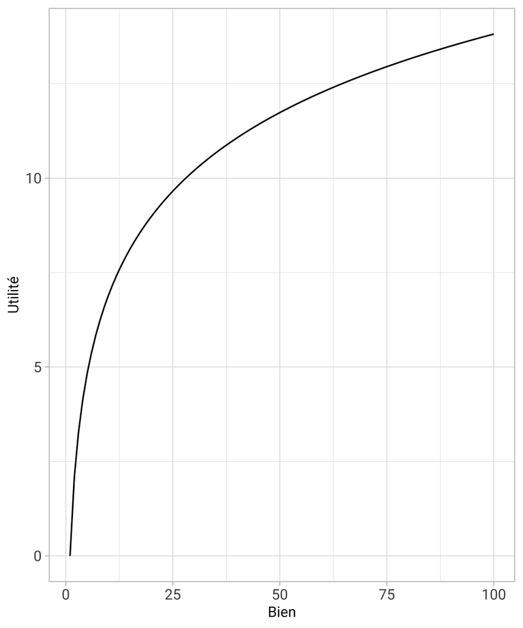

- William Stanley Jevons, Carl Menger et Léon Walras sont au coeur de ce qu’on appelle
- Révolution marginaliste : la valeur vient de la satisfaction des besoins, de l’utilité.
  - Les échanges et les prix sont plus importants que les processus productifs
- La question des ressources devient plutôt marginale :
  - L’aspectpsychologique de la théorie de la valeur s’occupe peu de rareté absolue,
  - Mais s’inquiète de la meilleure allocation de la richesse collective
  - La croissance est un peu oubliée jusqu’aux années 1950
- Il faut cependant gérer les ressources naturelles, les allouer proprement (efficacité allocative) et perdent leur statut nécessaire dans les flux biophysiques

## C. Le tournant du début du XXe siècle : marginalité de la matière

### Veblen (1857-1929)

- Représentant d’un courant clé de la pensée américaine : l’institutionalisme
  - Ensemble des règles formelles (lois, régulations) et informelles (normes, coutumes, conventions sociales)
  - Dans la structuration des comportements économiques et la configuration des interactions sociales
  - Qui façonnent plus que la rationalité l’économie
- Les institutions sont
  - des entités évolutives, qui changent au gré des transformations technolgoiques, culturelles et sociales
  - Mettant en avant un processus évolutif de l’économie et des institutions de façon conjointe

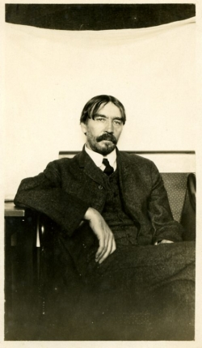

- *The theory of leisure class* (1899):
  - Parle le premier deconsommation ostentatoire : consommation d’une classe aisée et oisive, de façon visible et excessive pour montrer leur situation sociale
  - Le loisir, en outre de la consommation, est valorisé bien que apparemment dénué d’utilité economiquen, comme indicateur de statut
  - C’est inefficace, et l’accumulation avec ces motifs n’est pas souhaitable
  - De façon parallèle, crée des conditions pour plus de croissance : le désir de consommation est toujours lié à celui de la classe au dessus
  - Plus le prix d’un bien est élevé, plus on en veut dans une certaine classe
  - Forme les prémisses d’une étude des liens entre consommation et bonheur

### Conservationisme

[figure not shown]

Giford Pinchot

- Conservationnisme : courant de pensée visant à l’usage raisonnés des ressources naturelles
  - la rareté est une réalité inflexible ; elle peut se révéler comme une disponibilité physique limitée au niveau régional voire mondial, à un instant donné ou dans le temps
  - sans une intervention publique suffisante les forces du marché libre intensifieraient la rareté et créeraient de grands monopoles dominant la propriété des ressources naturelles

### Harold Hotelling (1875-1973) et l’analyse marginaliste des ressources

“L’économie des ressources épuisables”, *Journal of Political Economy*, 1931

- Modèle mathématique de l’exploitation des ressources
  - Vision allocative : trouver le prix qui permet une allocation optimale des ressources dans le temps
  - Il s’agit de savoir quels enjeux particuliers le secteur de l’extraction minière présente du point de vue d’un producteur rationnel cherchant à maximiser son profit.
  - Les préoccupations des classiques ou des institutionnalistes envers les réalités techniques de la production et de la croissance sont mises de côté.
- Règle de Hotelling :
  - Le prix de la ressource doit nécessairement évoluer de la sorte pour que les volontés de report et de précipitation de l’extraction s’équilibrent
  - via le calcul des variations :minimisation d’une forme fonctionnelle, on cherche la fonction et pas $x$ pour le faire, base du Lagrangien et Hamiltonien

$$\frac{\dot{P}_t}{P_t} = r$$

- Introduit des dimensions clé :
  - Actualisation et allocation des ressources dans le temps
  - Démonstration que l’exploitation par un régime concurrentiel donne une allocation optimale
- Le problème n’est plus macroéconomique
  - Il ne porte plus sur la dynamique du système économique, sur les mutations structurelles de l’économie.
  - Savoir comment capter un maximum de valeur à partir d’une ressource donnée de façon mathématique

### Karl Polanyi (1886-1964) et l’encastrement

*The Great Transformation*, 1944

- Idée d’un encastrement des mondes : le monde économique est inclus dans le social, lui même dans la nature
- Le libéralisme économique vise au désencastrement de la sphère économique et technique de la sphère sociale et politique :
  - L’économique devient traité comme un système autonome au règles arbitraires
  - Ce désencastrement produit des effets terribles, socialement, économiquement et environnementalement
- La marchandisation des éléments fondamentaux, qui ne devrait pas être possible “normalement” car pas produites
  - La terre (ou la nature) ne peut être considérée uniquement comme une marchandise sans conséquences écologiques et sociales.
  - Le travail, c’est-à-dire l’activité humaine, est soumis aux logiques de profit plutôt qu’à son rôle social et créatif.
  - La monnaie est transformée en un instrument purement spéculatif, déconnecté de sa fonction d’échange social.
- Auquel répond la sphère sociale dans un double mouvement :
  - Tension entre dérégulation : le marché, laissé à lui-même, peut engendrer des inégalités extrêmes et des instabilités qui nécessitent des interventions pour préserver la cohésion sociale; il ne s’autorégule pas
  - et protection accrue, parfois l’émergence de régimes totalitaires

### William Kapp (1910-1976) et les coûts sociaux

*The social costs of private enterprise* (1950)

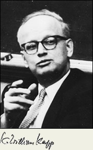

- Les coûts sociaux sont inhérents au régime de marché expansif et pas des externalités
  - L’entreprise privée, en se concentrant exclusivement sur la maximisation du profit
  - Néglige une large gamme de coûts supportés par la société.
  - Et cherche même à les transférer sur la société du fait du capitalisme
  - Ils ne sont inclus dans l’analyse coût bénéfice, ce qui ne permet pas une bonne allocation des ressources
- Prône une approche par les institutions, pour anticiper les coûts sociaux plutôt que de courir après
- Rejet des approches de consentement à payer
  - Fondées sur les «capacités à payer» des individus
  - Disent donc rien sur les dynamiques socio-écologiques et les risques cumulatifs
- Economie évolutionniste et développementaliste fondée sur une diversité d’indicateurs :
  - Balance économie/écologie avec objectif les besoins humains élémentaires pour tous

### Nicolas Georgescu Roegen (1906-1994) et le retour de la thermodynamique

*The Entropy Law and the economic process* (1971)

- Les phénomènes de production sont :
  - compris comme des processus de transformation et de dégradation de l’énergie
  - mais également de fragmentation et dissémination de la matière
- Met en avant le caractère irréversible des actions humaines:
  - et des processus écologiques, du fait de l’impossibilité de réutiliser la matière et l’énergie.
  - les matériaux ne pouvaient être recyclés infiniments, de ce fait, même une économie en non croissance est insoutenable : retour d’un “état stationnaire”
  - La limite basse serait un point où l’apport énergétique est assuré par le soleil
- Le phénomène d’entropie est accru par l’usage de nos «organes exosomatiques» (voitures, avions, tracteurs, etc.)
- Georgescu Roegen n’aimait pas la théorie de la valeur basée sur l’énergie, en mettant l’accent sur la matière en refus d’un dogme purement énergétique.

### K.E. Boulding (1910-1993) et l’analyse générale des systèmes

*The Economics of the Coming Spaceship Earth*, 1966

- L’économie des années 1960 comme l’économie « cow boy »:
  - Conquérant de nouveaux espaces, de nouvelles terres et de nouvelles ressources
  - Il faut passer à une économie du vaisseau spatial terre
  - Du fait des lois de la thermodynamique : énergie, eau, matière, présentes en quantités limitées, doivent être gérées raisonnablement.
  - Préconise de valoriser les actifs immatériels également, comme les connaissances
- A sa suite, Ayres et Knees :
  - développent le premier modèle économique fondé sur la comptabilité matérielle, qui aura une grande influence sur les premiers économistes écologiques
  - Montrent également que les « externalités » sont en fait nécessaires c’est à dire non pas contingentes mais normales dans le régime d’exploitation, résultant des lois de la physique

### Eugene Odum (1913-2002) et Buzz Holling (1930-2019) : l’écologie comme système

- Pionniers de l’analyse des écosystèmes
  - Insistent sur la dimension systémique des interrelations entre les organismes au sein d’une même espèce, entre les espèces, et plus largement, avec l’ensemble des éléments qui constituent l’écosystème
  - Les échanges entre biotiques et abiotique sont caractérisés comme des flux matériels et énergétiques
- Odum est pionnier d’une approche écoénergétique
  - Qui caractérise les flux d’énergie qui s’échangent entre composants d’un système, en les comptabilisant (énergie libérée et incorporée)
- Holling laisse de fameux concepts comme celui de résilience et de cycle adaptif
  - “Mesure de la capacité des systèmes à absorber des changements dans ses variables d’état, ses variables actives et ses paramètres, et à perdurer”
  - Le système économique encastré dans le système social et lui même inclus dans la biosphère, de façon dynamique avec la notion de cycle adaptif

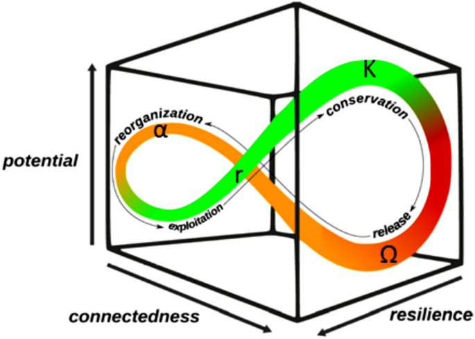

## Le constat des années 1970

- Après une mise à l’agenda dans les 1960 :
  - *Silent Spring* de Rachel Carson qui dénonce l’impact des pesticides sur les oiseaux
  - Mouvements contestataires en Europe (1968) et aux Etats Unis
- Retour de la question environnementale dans les années 1970 :
  - 1971 : Création du ministère de l’Environnement en France
  - 1972 : Conférence des Nations Unies sur l’environnement à Stockholm, premier sommet mondial sur l’environnement
  - 1973 : Premier choc pétrolier qui soulève la question de la dépendance aux énergies fossiles
  - Travaux du Club de Rome (dont le fameux rapport Meadows)

**The Limits to Growth, 1972**

Sous la houlette de Dennis Meadows, un rapport utilisant un modèle de simulation (`World3`) identifie l’industrialisation, la démographie, l’épuisement des ressources et la dégradation de l’environnement et prédit un effondrement du système mondial au XXIe siècle si la trajectoire de croissance reste inchangée. Les préconisations principales sont la transition vers un état d’équilibre (“steady state”) via le contrôle volontaire de la croissance démographique et économique, l’amélioration des techniques de production et la réduction de l’exploitation des ressources naturelles.

## Des pionniers de l’économie écologique

### Herman Daly (né en 1938)

*Steady State Economics (1977)*

### René Passet et la hiérarchie des systèmes de Passet (1926-)

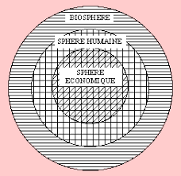

### Igancy Sachs (1927-2023) et l’éco développement v. le développement durable

*L’éco-développement* (1981)

- Pas d’objectif normatif généralisable
- Objectif de co-viabilité est contexte-dépendant
- Rôle clé d’instances de planification décentralisées et participatives
- Permettant la délibération entre citoyens-consommateurs-producteurs
- Doivent permettre l’adoption de décisions collectives adaptées aux besoins et au contexte écologique et social
- Faible succès car pas de programme assez «idéologique» mais une approche pragmatique

# La création du sous-champ

Le *“champ scientifique comme système des relations objectives entre les positions acquises (dans les luttes antérieures) est le lieu (c’est-à-dire l’espace de jeu) d’une lutte de concurrence qui a pour enjeu spécifique le monopole de l’autorité scientifique”* (P. Bourdieu, 1976)

## La critique et les principes clés

*Towards an ecological economics*, Costanza & Daly, 1987

- Petit à petit, une opposition se crée à la réponse des économistes, qui prônent la substituabilité des capitaux naturels et physiques
- Pas de système économique qui puisse vraiment prendre en compte les ressources naturelles :
  - Partisans du marché : les externalités ne sont pas importantes et le système peut être amélioré avec plus de main invisible
  - Les marxistes pensent qu’une meilleure planification et éducation politique va résoudre les problèmes
- L’écologie scientifique ignore l’aspect humain culturel:
  - On regarde l’impact des hommes sur les écosystèmes
  - Mais pas la « compréhension et prédiction » des comportements humains dans le contexte des écosystèmes naturels
- Il faut une science qui mêle les deux

Un des éléments principaux qui caractérise ce champ est l’intégration des sociétés humaines dans les écosystèmes et donc refus de la substituabilité parfaite des différentes formes de capitaux

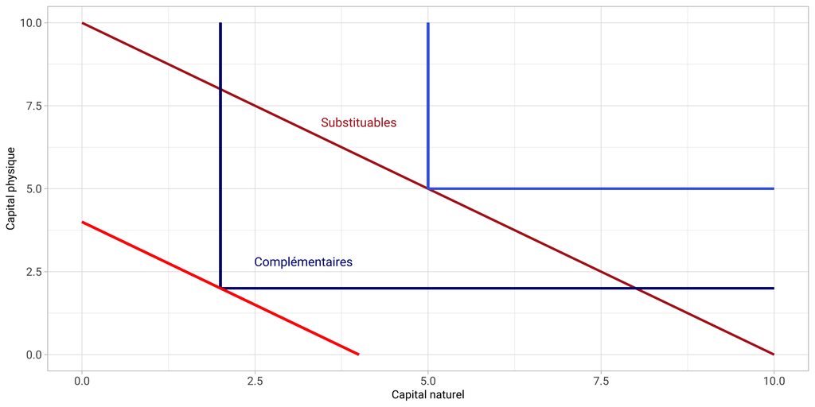

- La soutenabilité :les systèmes économiques existants n’arrivent pas à le prendre en compte, d’autres attributs du système comme la justice sont nécessaires
- Il faut modérer la place des humains par rapport aux autres espèces:
  - En intégrant leur valeur in « maintaining life support systems »
  - Et la valeur intrinsèques des autres espèces
- La question de la distribution des richesses et de la “suffisiency”:
  - Chez les humains, différents usages des ressources:
    - Par classes sociales
    - Dans le temps,
  - La limitation de la population n’est pas le seul levier,
  - La justice est clé pour faire la soutenabilité à l’intérieur de notre espèce
  - A la fois de façon intra et intergénérationelle
- La distribution des ressource intra et inter espèces:
  - Aussi avec les animaux : ils ont un niveau uniforme de revenu per capita, des dominances spatiales etc, mais pas de division en classes sociales.
- L’incertitude, sur les systèmes sociaux et naturels, est une caractéristique fondamentale
  - On s’occupera de principe de précaution, ou de résilience
- Un pluralimse méthodologique et épistémologique (Norgaard, 1989, 1994)
  - Revendique une ouverture aux différentes méthodes: sciences sociales, mathématiques, modélisation, approches de terrain
  - Ainsi qu’une approche transdisciplinaire : entre et à travers les disciplines pour faire dialoguer environnement et société
  - Et valeurs : pas forcément obligé de monétariser toute la nature, qui a une valeur intrinsèque, d’autres référentiels de pensée sont possibles, il faut essayer d’ouvrir la réflexion ailleurs
  - Qui peut tendre à la “big tent” : on y accepte un peu tout, il n’y a pas vraiment d’unité épistémologique (i.e. comment nous connaissons la réalité) ni ontologique (i.e. qu’est ce que la réalité, de quoi est elle composée, quelle est la nature des éléments
- Quelques pistes épistémologiques, ontologiques, et éthiques:
  - Tout n’est pas socialement construit : la thermodynamique est un processus physique, posant des limites claires
  - Ceci dit, la “réalité” est difficile à saisir et mesurer : il y’a différentes manières de s’en emparer
  - Les réalités sont de plus en plus difficiles à saisir en changeant d’échelle et le processus de la science doit être plus inclusif
  - Il y’a un statut éthique associé au non humain, qu’il faut moralement respecter et protéger
  - Trouver un milieu entre le réductionnisme de l’environnement à ses caractéristiques et le constructivisme qui nie les contraintes biophysiques terrestre
  - Tout en cherchant une science qui puisse dire des choses vraies, sans penser qu’il n’y a qu’une seule vérité ou réponse

Types de méthodes de raisonnement

- Par exemple, transition de la méthode hypothético-déductive
  - Hypothèse -> vérification expérimentale -> Lois généralisables
  - Initialement en science physique puis en sciences humaines
  - Dominante en science depuis le 19ème siècle
- Vers une démarche empirico-inductive
  - Question -> terrain -> hypothèses -> retour sur le terrain -> théorie situées temporellement et spatialement
  - Admet une diversité de méthodes pour répondre à la question
  - Utile pour les questions complexes et multi-factorielles Pluralisme disciplinaire

Pensée en système plutôt que par réductionnisme:

- Réductionnisme de la complexité à des composantes élémentaires, adaptée à :
  - L’étude de systèmes stables
  - Constitués de nombres limités d’éléments
  - En interaction linéaire (décrite par des lois mathématiques proportionnelles, additives etc)
- Passé un certain niveau de complexité (i.e. comportement d’un système dont les composants interagissent localement et de façon non linéaire) :
  - Systèmes non stables
  - Avec un grand nombre d’éléments ou de non linéarités
  - D’incertitudes
  - De possibilités de propriétés émergentes etc)
- Au delà de l’analyse des états stables, il convient d’analyser les trajectoires dynamiques via différents principes
  - Identifier la structure du système et les principes internes qui le constituent et le délimitent (structuralisme)
  - Identifier la qualité (ce qu’il y a, notamment l’information) dans les échanges
  - Analyser les rapports entre tous les niveaux d’organisation du système, comme en biologie, passer de l’individu à la biodiversité par exemple; une logique ou des logiques globales de fonctionnement

## Emergence de l’économie écologique comme champ

- Dans les années 80 des économistes et des écologues échangent autour des questions de durabilité International Society for Ecological Economics (ISEE) créée en 1987 à Barcelone
- Le journal *Ecological Economics* est créé en 1989
- Objectif réunir des scientifiques issus de l’écologie et de l’économie et ouvrir les méthodes d’analyse transdisciplinaire et interdisciplinaire / durabilité
- Des membres importants :
  - Robert Costanza (écologue)
  - Richard Norgaard (économiste)
  - Carl Folke (écologue)
  - Herman Daly (économiste),
  - AnnMari Jansson (écologue)
  - Joan Martinez-Alier (économiste)
  - David Pearce (économiste)

# 35 ans plus tard, où en est on?

3 grandes tendances : de “superficiel” à “profond” (Spash, 2015) - La nouvelle économie des ressources - L’approche du pragmatisme environnementaliste - La socioéconomie écologique

Voir les travaux de Spash (Chapitre 2 - Handbook), et [Ropke (2005)](https://www.uvm.edu/~jfarley/EEseminar/readings/ropke%20trends.pdf)

## La nouvelle économie des ressources

- Branche qui a pris à bras le corps l’écologie scientifique et approfondit sa prise en compte
- Dans des contextes spécifiques, s’attache à complexifier l’analyse des marchés en liens avec les écosystèmes locaux
- Ne porte pas en elle le même critique originelle parfois, vue comme un rejeton de l’économie néoclassique:
  - Individualisme méthodologique souvent
  - Relative indépendance des structures
- La modélisation bioéconomique par exemple (voir [Lauriane Mouysset](https://laurianemouysset.wordpress.com/)), constitue un langage commun pour revivifier et permet d’élaborer des nouvelles perspectives politiques.

## L’approche environnementaliste pragmatique

- Le but de cette approche, c’est de parler aux décideurs publics devant l’urgence, dans un système institutionnel donné (néo-libéralisme)
- Pour faire cela, elle investit le champ scientifique, politique et financier de notions écologiques qui sont transformées en grandeurs économiques monétarisées
- “We protect what we value”:
  - Services écoystémiques
  - Capital naturel
- Les travaux de Robert Costanza sont très connus, notamment sur l’évaluation économique de la Nature
- Peut être critiqué comme une approche de “problem solving” plutôt que de réfléxion plus fondamentale sur les liens entre humanité et nature

## La socioéconomie de l’environnement

- Volonté de se détacher des monétarisations, de l’approche pragmatique
  - Les méthodes scientifiques participent d’une confrontations entre ce que M. Foucault appelle des “savoirs-pouvoirs”
  - Il existe plein de manière de se représenter la “nature” ou l’environnement et autant de manière d’en produire des évaluations: l’imaginaire et les valeurs de l’environnement sont des champs de bataille
    - Ex : C’est pas pareil de regarder un troupeau de bovin avec des lunettes productiviste (combien de kg de viande, et prix de marché) ou avec une éthique bio (santé animale, bien-être, etc.)
    - Ex2 : On peut regarder des jardins populaires urbains comme un lieu de sociabilité et de relations avec le vivant, ou comme une “friche” susceptible d’accueillir de nouveaux logements ((caricatural exprès))
  - Les rapports de force en vigueur dans une société engendrent des formes de valorisation dominante, et donc des régimes de rapport à l’environnement
  - Il y a un lien entre la production et la mise en circulation des connaissances (savoirs) et la manière dont on agit sur l’environnement (pouvoirs).
- Volonté de s’approcher d’une analyse des institutions, des systèmes producteurs d’équité
- Se veut faire une économie non pas dépolitisée, mais la critique des dynamiques institutionnelles dans le cadre de la transition

### Le lien entre savoir et pouvoir chez Michel Foucault

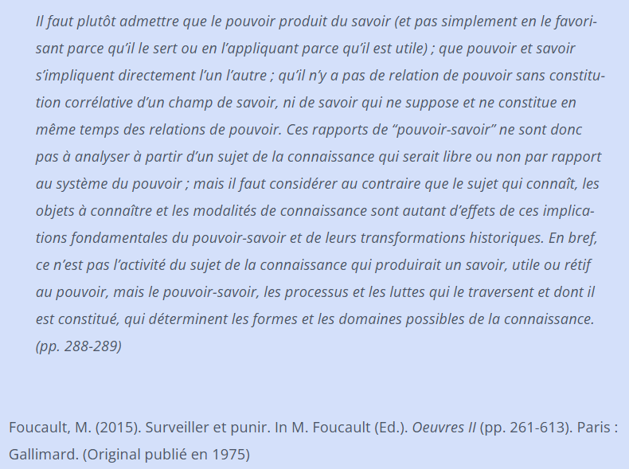

## Les grandes questions de ce cours

1. Comment caractériser le lien que les sociétés humaines ont avec l’énergie et la matière? Comment caractériser notre impact sur la planète et ses limites? Quelles sociétés créent les différents liens à la matière?
2. Compte tenu des limites planétaires, quelles politiques économiques peut-on mettre en place? Comment piloter les sociétés humaines? Quels risques sont ils liés à des transitions?
3. Comment prendre en compte plus spécifiquement les limites liées au vivant? Quelles institutions mettre en place pour éviter son effondrement effondrement?
4. Comment opérer des transitions institutionnelles, à de multiples échelles? Quelles modes d’organisation collectives mettre en place et comment?
5. Quelles valeurs et modes de pensée développer pour collectivement demeurer sur une Terre habitable? Comment revisiter la construction de la science et du discours normatif?
6. Quelles perspectives de réflexion pour l’avenir, dans un cadre de transition écologique juste intra et intergénérationelles, liées au genre, à la domination raciale etc?